# IV Problem Set

Guo Zhan

2026-02-21

## 1. Load data

```r
df = read.csv("/Users/norazhan/Desktop/Y1T2/ppol5201_stat/IV/iv_problem_set.csv", stringsAsFactors = FALSE)
nrow(df)
```

```
## [1] 100000
```

```r
names(df)
```

```
## [1] "S"           "compulsoryS" "female"      "xpr"         "xpr2"
## [6] "lnearn"
```

## 2. Regression

```r
m1 = lm(lnearn ~ female + S + xpr + xpr2, data = df)
summary(m1)
```

```
##
## Call:
## lm(formula = lnearn ~ female + S + xpr + xpr2, data = df)
##
## Residuals:
##     Min      1Q  Median      3Q     Max
## -5.1370 -0.8165 -0.0015  0.8203  5.7465
##
## Coefficients:
##               Estimate Std. Error t value Pr(>|t|)
## (Intercept)  6.923e+00  2.406e-02  287.77   <2e-16 ***
## female       1.322e+00  7.635e-03  173.08   <2e-16 ***
## S            1.514e-01  1.501e-03  100.89   <2e-16 ***
## xpr          4.904e-02  1.639e-03   29.92   <2e-16 ***
## xpr2        -7.962e-03  4.422e-05 -180.04   <2e-16 ***
## ---
## Signif. codes:  0 '***' 0.001 '**' 0.01 '*' 0.05 '.' 0.1 ' ' 1
##
## Residual standard error: 1.207 on 99995 degrees of freedom
## Multiple R-squared:  0.817,  Adjusted R-squared:  0.817
## F-statistic: 1.116e+05 on 4 and 99995 DF,  p-value: < 2.2e-16
```

One additional year of schooling is associated with about 0.1514 log points higher earnings. The t-statistic for $S$ is 100.89 with p < 2e-16, so the return is highly statistically significant, and we can reject the hypothesis that the return to schooling is 0.

## 3. Endogeneity

**Omitted variables (ability/family background/motivation):** People with higher ability, better health, stronger motivation, richer networks, or more advantaged families often both get more schooling and earn more for reasons not captured by $xpr$ and $xpr^2$. Those factors go into the error term.

**Measurement error in schooling:** If years of schooling are measured with error, classical measurement error makes $S$ correlated with the error term and usually biases the coefficient toward zero (attenuation).

**Reverse causality/selection:** Expected earnings (or opportunities) can affect schooling decisions, e.g., someone who anticipates high returns chooses more schooling, or someone with good job offers leaves school earlier. That makes causality run partly from earnings prospects to schooling, again violating exogeneity.

## 4. Compulsory schooling as IV

Inclusion condition: If a state requires more compulsory schooling, people exposed to that rule should, on average, complete more years of education. In other words, Cov($compulsoryS$, $S$) does not equal 0 ($compulsoryS$ is statistically significant in the first stage regression of $S$ on $compulsoryS$ and controls).

Exclusion condition: $CompulsoryS$ must influence $lnearn$ only by changing $S$, not through any other pathway. If states with higher compulsory schooling also have better schools, higher wages, different industries, or other policies that directly raise earnings, the exclusion restriction fails.

## 5. Graphical evidence

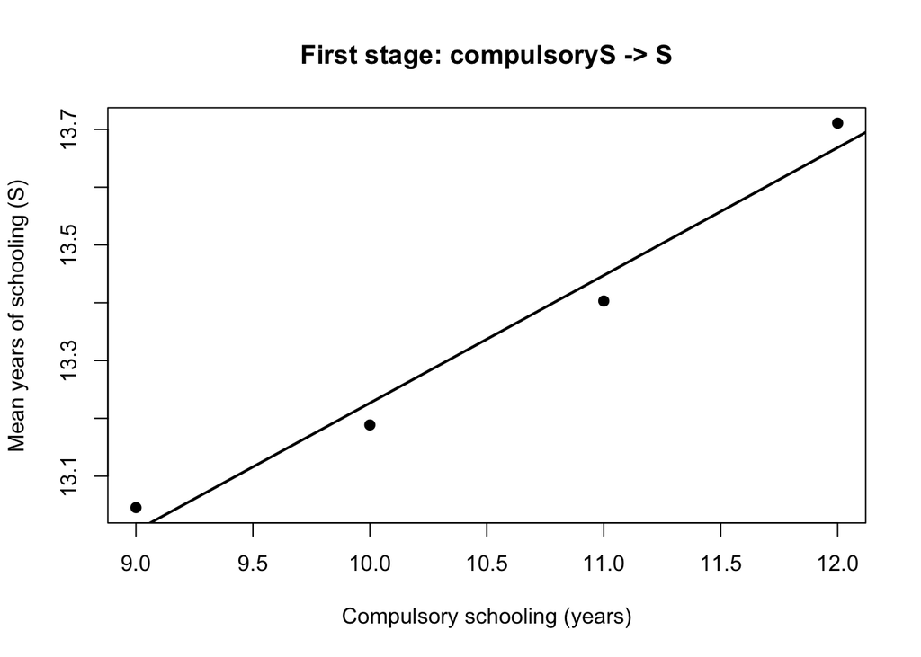

```r
# Collapse to means by compulsory schooling (so the plot is readable)
agg = aggregate(cbind(S, lnearn) ~ compulsoryS, data = df, FUN = mean)

# First stage
plot(
  x = agg$compulsoryS, y = agg$S,
  xlab = "Compulsory schooling (years)", ylab = "Mean years of schooling (S)",
  main = "First stage: compulsoryS -> S",
  pch = 19
)
abline(lm(S ~ compulsoryS, data = agg), lwd = 2)
```

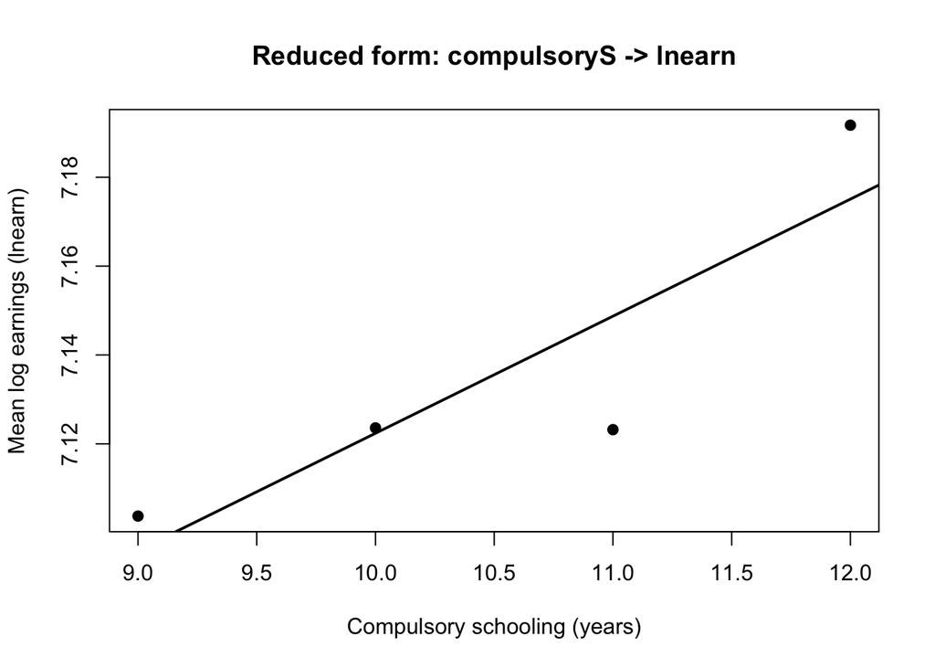

```r
# Reduced form
plot(
  x = agg$compulsoryS, y = agg$lnearn,
  xlab = "Compulsory schooling (years)", ylab = "Mean log earnings (lnearn)",
  main = "Reduced form: compulsoryS -> lnearn",
  pch = 19
)
abline(lm(lnearn ~ compulsoryS, data = agg), lwd = 2)
```

The first-stage graph shows a clear positive relationship between $compulsoryS$ and actual years of schooling ($S$): states with higher compulsory schooling requirements (from about 9 to 12 years) have higher average completed schooling. This visually supports the inclusion condition, i.e., the instrument meaningfully shifts schooling.

The reduced-form graph shows that $compulsoryS$ is also positively related to mean log earnings ($lnearn$): higher compulsory schooling requirements are associated with higher average log earnings. This indicates that the policy variation has an observable effect on earnings outcomes.

Taken together, these two graphs motivate the IV strategy pretty well: compulsory schooling laws generate exogenous, policy-driven variation in education (first stage), and that same variation is associated with differences in earnings (reduced form).

## 6. First stage regression

```r
fs = lm(S ~ compulsoryS, data = df)
summary(fs)
```

```
##
## Call:
## lm(formula = S ~ compulsoryS, data = df)
##
## Residuals:
##     Min      1Q  Median      3Q     Max
## -5.6539 -2.2132 -0.2132  2.3461  5.0071
##
## Coefficients:
##              Estimate Std. Error t value Pr(>|t|)
## (Intercept) 11.010002   0.088157  124.89   <2e-16 ***
## compulsoryS  0.220323   0.008364   26.34   <2e-16 ***
## ---
## Signif. codes:  0 '***' 0.001 '**' 0.01 '*' 0.05 '.' 0.1 ' ' 1
##
## Residual standard error: 2.535 on 99998 degrees of freedom
## Multiple R-squared:  0.006891,   Adjusted R-squared:  0.006881
## F-statistic: 693.9 on 1 and 99998 DF,  p-value: < 2.2e-16
```

From the first-stage regression, the estimated effect of compulsory schooling on schooling is 0.220, with a t-statistic of 26.34, which is way larger than 3 (the rule of thumb). So $compulsoryS$ is a highly statistically significant predictor of schooling.

## 7. ivreg

```r
#install.packages("AER")
library(AER)
iv = ivreg(lnearn ~ female + S + xpr + xpr2 | female + compulsoryS + xpr + xpr2, data = df)

summary(iv)
```

```
##
## Call:
## ivreg(formula = lnearn ~ female + S + xpr + xpr2 | female + compulsoryS +
##     xpr + xpr2, data = df)
##
## Residuals:
##       Min        1Q    Median        3Q       Max
## -5.155304 -0.816166 -0.001561  0.819575  5.728230
##
## Coefficients:
##               Estimate Std. Error  t value Pr(>|t|)
## (Intercept)  6.777e+00  2.414e-01   28.077   <2e-16 ***
## female       1.322e+00  7.638e-03  173.025   <2e-16 ***
## S            1.623e-01  1.808e-02    8.976   <2e-16 ***
## xpr          4.904e-02  1.639e-03   29.920   <2e-16 ***
## xpr2        -7.962e-03  4.423e-05 -179.996   <2e-16 ***
## ---
## Signif. codes:  0 '***' 0.001 '**' 0.01 '*' 0.05 '.' 0.1 ' ' 1
##
## Residual standard error: 1.208 on 99995 degrees of freedom
## Multiple R-Squared: 0.8169,  Adjusted R-squared: 0.8169
## Wald test: 1.09e+05 on 4 and 99995 DF,  p-value: < 2.2e-16
```

The IV estimate (0.1623) is slightly higher than the OLS estimate (0.1514). Both are statistically significant here, but IV comes with a much larger standard error—as expected, because IV uses only the variation in schooling generated by the instrument (compulsory schooling laws), which is “weaker” information than the full variation used by OLS.

## 8. Two variables to be instrumented

```r
df$femaleS = df$female * df$S
df$female_compS = df$female * df$compulsoryS

# First stage for S
fs_S = lm(S ~ female + xpr + xpr2 + compulsoryS + female_compS, data = df)
summary(fs_S)
```

```
##
## Call:
## lm(formula = S ~ female + xpr + xpr2 + compulsoryS + female_compS,
##     data = df)
##
## Residuals:
##     Min      1Q  Median      3Q     Max
## -5.6636 -2.2193 -0.2258  2.3361  5.0164
##
## Coefficients:
##                Estimate Std. Error t value Pr(>|t|)
## (Intercept)   1.104e+01  1.273e-01  86.725   <2e-16 ***
## female       -4.409e-02  1.763e-01  -0.250    0.803
## xpr          -1.558e-03  3.441e-03  -0.453    0.651
## xpr2          3.993e-05  9.287e-05   0.430    0.667
## compulsoryS   2.185e-01  1.185e-02  18.441   <2e-16 ***
## female_compS  3.725e-03  1.673e-02   0.223    0.824
## ---
## Signif. codes:  0 '***' 0.001 '**' 0.01 '*' 0.05 '.' 0.1 ' ' 1
##
## Residual standard error: 2.535 on 99994 degrees of freedom
## Multiple R-squared:  0.006895,   Adjusted R-squared:  0.006845
## F-statistic: 138.8 on 5 and 99994 DF,  p-value: < 2.2e-16
```

```r
# First stage for female*S
fs_femaleS = lm(femaleS ~ female + xpr + xpr2 + compulsoryS + female_compS, data = df)
summary(fs_femaleS)
```

```
##
## Call:
## lm(formula = femaleS ~ female + xpr + xpr2 + compulsoryS + female_compS,
##     data = df)
##
## Residuals:
##     Min      1Q  Median      3Q     Max
## -5.6567 -0.4308  0.0002  0.0012  5.0135
##
## Coefficients:
##                Estimate Std. Error t value Pr(>|t|)
## (Intercept)   2.669e-03  9.011e-02   0.030    0.976
## female        1.099e+01  1.248e-01  88.066   <2e-16 ***
## xpr          -2.405e-04  2.435e-03  -0.099    0.921
## xpr2          3.621e-06  6.572e-05   0.055    0.956
## compulsoryS   1.253e-05  8.384e-03   0.001    0.999
## female_compS  2.222e-01  1.184e-02  18.767   <2e-16 ***
## ---
## Signif. codes:  0 '***' 0.001 '**' 0.01 '*' 0.05 '.' 0.1 ' ' 1
##
## Residual standard error: 1.794 on 99994 degrees of freedom
## Multiple R-squared:  0.9324, Adjusted R-squared:  0.9324
## F-statistic: 2.757e+05 on 5 and 99994 DF,  p-value: < 2.2e-16
```

First stage for S: $compulsoryS$ coefficient = 0.2185, t = 18.44, p < 2e-16: strong, statistically significant predictor of S. $female_compS$ coefficient = 0.0037, p = 0.824: not a significant predictor of S. Conclusion: For the schooling level S, the relevant instrument is $compulsoryS$ (strong). The interaction instrument doesn’t add predictive power for S.

First stage for $female*S$: $female_compS$ coefficient = 0.2222, t = 18.77, p < 2e-16: strong, statistically significant predictor of female·S. $compulsoryS$ coefficient ≈ 0.0000, p = 0.999: no predictive power for female·S. Conclusion: For the interaction term female·S, the relevant instrument is $female·compulsoryS$ (strong). $CompulsoryS$ alone doesn’t move the interaction.

## 9. IV results comparison

```r
iv2 = ivreg(
  lnearn ~ female + xpr + xpr2 + S + femaleS |
    female + xpr + xpr2 + compulsoryS + female_compS,
  data = df
)

summary(iv2)
```

```
##
## Call:
## ivreg(formula = lnearn ~ female + xpr + xpr2 + S + femaleS |
##     female + xpr + xpr2 + compulsoryS + female_compS, data = df)
##
## Residuals:
##        Min         1Q     Median         3Q        Max
## -5.1943454 -0.8125815 -0.0001014  0.8170772  5.6894355
##
## Coefficients:
##               Estimate Std. Error  t value Pr(>|t|)
## (Intercept)  7.093e+00  3.433e-01   20.664  < 2e-16 ***
## female       6.979e-01  4.801e-01    1.454    0.146
## xpr          4.901e-02  1.633e-03   30.015  < 2e-16 ***
## xpr2        -7.961e-03  4.407e-05 -180.647  < 2e-16 ***
## S            1.386e-01  2.573e-02    5.387 7.18e-08 ***
## femaleS      4.681e-02  3.603e-02    1.299    0.194
## ---
## Signif. codes:  0 '***' 0.001 '**' 0.01 '*' 0.05 '.' 0.1 ' ' 1
##
## Residual standard error: 1.203 on 99994 degrees of freedom
## Multiple R-Squared: 0.8183,  Adjusted R-squared: 0.8183
## Wald test: 8.789e+04 on 5 and 99994 DF,  p-value: < 2.2e-16
```

From the IV regression where $S$ and $female·S$ are instrumented by $compulsoryS$ and $female·compulsoryS$: The IV estimate on $female·S$ is 0.0468 (SE = 0.0360), with t = 1.299 and p = 0.194. So we cannot reject the null hypothesis that the coefficient on $female·S$ is 0 at conventional significance levels (e.g., 5% or 10%).

The coefficient on S is 0.1386 (p < 0.001), which is the estimated return to schooling for males (female = 0): about 13.9% per additional year in log terms. For females, the implied return is 0.1386 + 0.0468 = 0.1854 (about 18.5% per year in log terms).

However, because $female·S$ is not statistically significant, the data do not provide strong evidence (under IV) that the return to schooling differs by gender. The point estimate suggests a higher return for women, but it’s imprecise and not distinguishable from zero.